# Ethogram Data Collection 2 - Outcome (Success, Fail)

Marinara Marcato

# 1 Introduction

This document shows the data analysis carried out to investigate the association between ethogram scores filled out by two trainers and the dog’s training outcome. Statistical methods will be used to test the hypothesis that there is a relationship between ethogram scores at dc2 and training outcome (Success, Fail).

# 2 Data Exploration

The dataset comprised of the following types and number of variables. The original ethogram items contained ordinal and categorical variables. The score variables were numerical derived from the original ethogram items.

```
##
## categorical    comments        info     ordinal       score        time
##          17          16          17          53          42          25
##      unused
##          11
```

```
## [1] "Success" "Fail"
```

All ordinal (N = 53) and categorical (N = 17) variables from the original ethogram items, score (N = 42) variables derived from the original ethogram items and demographical variables (N = 2) - namely, Sex and Breed - will be analysed.

## 2.1 Demographics

Overview of the dogs participating in the data collection. Inclusion criteria: only Labrador Retrievers (LR) and Labrador Retrievers crossed with Golden Retrievers (LRxGR) were kept for data analysis.

```
## Original dataset (dogs, variables):  61 133
```

```
##
##    GR    LR   LRx LRxGR
##     1    25    12    23
```

```
##
##    LR LRxGR
##    25    35
```

```
## Final dataset (dogs, variables):  60 133
```

```
##
## Success    Fail
##      50      10
```

```
##
##   Success      Fail
## 0.8333333 0.1666667
```

```
##
##  F  M
## 32 28
```

Calculate descriptive statistics for age at arrival at the training centre for formal training. Calculate descriptive statistics for age at assessment when the dogs performed the behaviour test at data collection 1, which should be around week 3 of formal training.

```
## Age at Arrival: Mean 15.28 Standard Deviation 1.88 Minimum: 12.59 Maximum: 21.9
```

```
## Age at Assessment: Mean 17.81 Standard Deviation 1.84 Minimum: 15.32 Maximum: 24.36
```

Calculate statistics of duration of training for the dogs that were withdrawn from training. Performing this behaviour test at the beginning on the training (Week 3) would allow assistance dog training organisations to understand which dog are more suitable and allow them to make informed decisions when analysing which dogs to keep for training considering the results of this objective assessment.

```
## [1] "Duration of Training in weeks"
```

```
##     Duration
##  Min.   :10.43
##  1st Qu.:14.21
##  Median :16.29
##  Mean   :17.29
##  3rd Qu.:16.82
##  Max.   :29.57
```

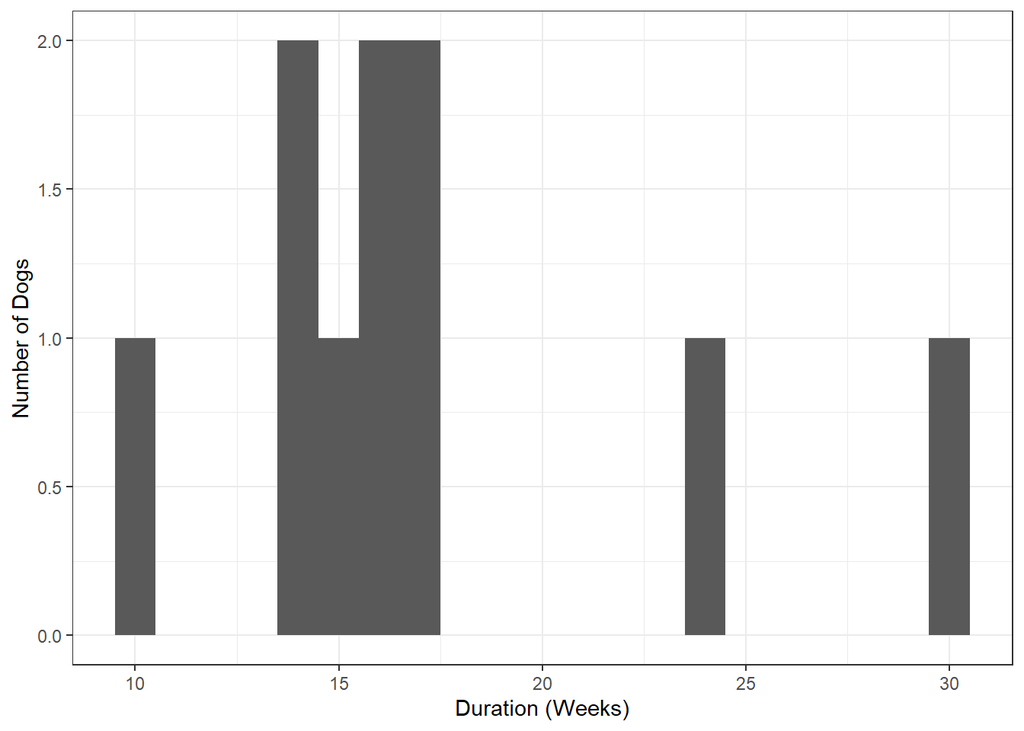

## 2.2 Descriptive Statistics

```
## dataframe saved to  3_analysis/dc2-new/descriptive-statistics-numerical.csv
```

```
##                                                                  No Yes NA.s
## Body.check.General..Mouths.                                      60  60    0
## Body.check.General..Licks.                                       56   4    0
## Tea.Towel.First.Response..Indifferent.                           52   8    0
## Tea.Towel.First.Response..Change.from.Neutral.                    9  51    0
## Tea.Towel.First.Response..Turns.head.                            13  47    0
## Tea.Towel.First.Response..Attempts.to.Removes.towel.by.moving.   34  26    0
## Tea.Towel.First.Response..Attempts.to.Removes.towel.with.mouth.  33  27    0
## Tea.Towel.First.Response..Plays.                                 52   8    0
## Tea.Towel.Second.Response..Indifferent.                          38  22    0
## Tea.Towel.Second.Response..Turns.head.                           29  31    0
## Tea.Towel.Second.Response..Change.from.Neutral.                  21  39    0
## Tea.Towel.Second.Response..Attempts.to.Removes.towel.by.moving.  40  20    0
## Tea.Towel.Second.Response..Attempts.to.Removes.towel.with.mouth. 40  20    0
## Tea.Towel.Second.Response..Plays.                                53   7    0
## Crate.Urinating                                                  60  60    0
## Isolation.Urinating                                              59   1    0
```

```
## dataframe saved to  3_analysis/dc2-new/descriptive-statistics-ordinal.csv
```

```
## dataframe saved to  3_analysis/dc2-new/kong-lateralisation.csv
```

## 2.3 Feature Selection

Metholodogy adapted from Hosmer2013, pg 107 (GLOW study example).

### 2.3.1 Step 1: Univariate logistic regression model results.

Features which achieved P < 0.25 were selected for consideration to be included in the reduced feature set. Subsequentely, related variables were removed considering two cases: - Two scores: when both the mean and product scores were selected, the score with the highest p-value was removed. - Score and original items: when both the original item and the score derived from it were selected, the one with the highest p-value was removed.

```
## [1] "X1" "X2" "X3" "X4" "X5" "X6" "X7" "X8" "X9"
```

```
## Categorical variable with 4 factors: Both Left None Righ
```

```
## $Kong.Interaction.Lateralisation
##
## Call:
## glm(formula = Outcome ~ x, family = binomial(link = logit), data = dc_cat,
##     na.action = na.exclude)
##
## Deviance Residuals:
##     Min       1Q   Median       3Q      Max
## -0.9005  -0.5168  -0.4590  -0.4366   2.1899
##
## Coefficients:
##             Estimate Std. Error z value Pr(>|z|)
## (Intercept)  -0.6931     0.6124  -1.132    0.258
## xLeft        -1.2528     0.9728  -1.288    0.198
## xNone        -1.5041     0.9646  -1.559    0.119
## xRigh        -1.6094     1.2143  -1.325    0.185
##
## (Dispersion parameter for binomial family taken to be 1)
##
##     Null deviance: 50.397  on 58  degrees of freedom
## Residual deviance: 47.038  on 55  degrees of freedom
##   (1 observation deleted due to missingness)
## AIC: 55.038
##
## Number of Fisher Scoring iterations: 4
```

Ordinal: 7 out of 53 ethogram items. Score: 10 out of 42 variables.

Save results from univariate analysis.

```
## dataframe saved to  3_analysis/dc2-new/univariate-logistic regression.csv.csv
```

```
## dataframe saved to  3_analysis/dc2-new/significant-variables-25.csv.csv
```

[output not shown]

```
## [1] "Kong.Interaction.Back"
## [2] "Crate.Behaviours..Sniffing.Exploring.."
## [3] "Crate.Behaviours..Actively.Seeking.Attention."
## [4] "S.Familiarisation.Handler_prod"
## [5] "S.Isolation.Handler_mean"
```

```
##  [1] "Familiarisation.Response..Oriented.to.Handler."
##  [2] "Familiarisation.Response..Waiting."
##  [3] "Walking.Pull.on.leash"
##  [4] "Walking.Pull.strength"
##  [5] "Walking.Initiative"
##  [6] "Body.check.Table"
##  [7] "Distractions.First.Response..Car."
##  [8] "Distractions.Second.Response..Car."
##  [9] "Kong.Interaction.Response.to.stimulus"
## [10] "Kong.Interaction.Back"
## [11] "Kong.Return.Handler"
## [12] "Crate.Behaviours..Sniffing.Exploring.."
## [13] "Crate.Behaviours..Actively.Seeking.Attention."
## [14] "Crate.Behaviours..Whining."
## [15] "Isolation.Response..Time.oriented."
```

[output cut: 19 more lines]

```
##  [1] "Body.check.Table"
##  [2] "Distractions.First.Response..Car."
##  [3] "Kong.Interaction.Response.to.stimulus"
##  [4] "Kong.Return.Handler"
##  [5] "Isolation.Response..Time.oriented."
##  [6] "S.Walking.Pull_mean"
##  [7] "S.Familiarisation.Handler_mean"
##  [8] "S.Isolation.Stimulus"
##  [9] "Kong.Interaction.Lateralisation"
## [10] "Outcome"
```

```
##                                       p_value_1
## S.Familiarisation.Handler_mean           0.0734
## Body.check.Table                         0.0692
## Isolation.Response..Time.oriented.       0.0446
## Kong.Return.Handler                      0.0382
## S.Isolation.Stimulus                     0.0336
## S.Walking.Pull_mean                      0.0237
## Distractions.First.Response..Car.        0.0182
## Kong.Interaction.Response.to.stimulus    0.0136
```

### 2.3.2 Step 2: Correlation

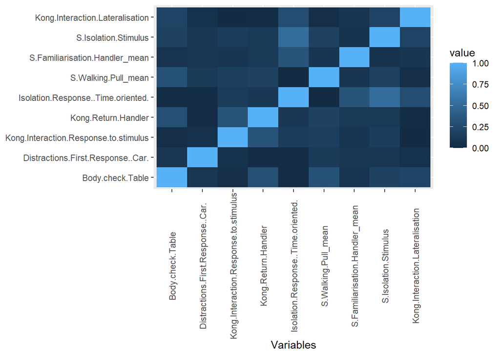

```
## [1] "S.Isolation.Stimulus"
```

```
## [1] "Body.check.Table"
## [2] "Distractions.First.Response..Car."
## [3] "Kong.Interaction.Response.to.stimulus"
## [4] "Kong.Return.Handler"
## [5] "Isolation.Response..Time.oriented."
## [6] "S.Walking.Pull_mean"
## [7] "S.Familiarisation.Handler_mean"
## [8] "Kong.Interaction.Lateralisation"
## [9] "Outcome"
```

### 2.3.3 Step 3: Multivariate model

The first multivariate model was built using the features selected in the step above. Then, the feature with the highest p-value above 20% significant level in the multivariate model was removed from the dataset. Another multivariate model was built and the procedure was repeated until no feature had a p-value above 20%. The difference in deviance was monitored to make sure the variable did not significantly affect model fitness.

```
## [1] "Initial multivariate model"
```

```
##
## Call:
## glm(formula = Outcome ~ ., family = binomial(link = logit), data = data_2)
##
## Deviance Residuals:
##        Min          1Q      Median          3Q         Max
## -1.313e-04  -2.100e-08  -2.100e-08  -2.100e-08   1.495e-04
##
## Coefficients:
##                                        Estimate Std. Error z value Pr(>|z|)
## (Intercept)                              676.63  159046.44   0.004    0.997
## Body.check.Table                        -204.90   33007.95  -0.006    0.995
## Distractions.First.Response..Car.         71.07   12255.65   0.006    0.995
## Kong.Interaction.Response.to.stimulus    413.98   60151.15   0.007    0.995
## Kong.Return.Handler                      -83.75   15985.95  -0.005    0.996
## Isolation.Response..Time.oriented.        34.19    7889.54   0.004    0.997
## S.Walking.Pull_mean                     -311.31   45904.68  -0.007    0.995
## S.Familiarisation.Handler_mean          -680.37   99491.45  -0.007    0.995
## Kong.Interaction.LateralisationLeft     -717.21  108187.96  -0.007    0.995
## Kong.Interaction.LateralisationNone     -239.95   42866.25  -0.006    0.996
## Kong.Interaction.LateralisationRigh      -64.04   40200.51  -0.002    0.999
##
## (Dispersion parameter for binomial family taken to be 1)
##
##     Null deviance: 5.0063e+01  on 57  degrees of freedom
## Residual deviance: 1.0749e-07  on 47  degrees of freedom
##   (2 observations deleted due to missingness)
## AIC: 22
##
## Number of Fisher Scoring iterations: 25
```

```
##
## Call:
## glm(formula = Outcome ~ ., family = binomial(link = logit), data = data_3)
##
## Deviance Residuals:
##      Min        1Q    Median        3Q       Max
## -1.77515  -0.21467  -0.06811  -0.00570   2.32125
##
## Coefficients:
##                                   Estimate Std. Error z value Pr(>|z|)
## (Intercept)                         2.7577     3.1389   0.879  0.37964
## Distractions.First.Response..Car.   2.2474     0.9434   2.382  0.01721 *
## S.Walking.Pull_mean                -4.7151     1.6486  -2.860  0.00424 **
## S.Familiarisation.Handler_mean     -3.4410     1.4528  -2.369  0.01786 *
## ---
## Signif. codes:  0 '***' 0.001 '**' 0.01 '*' 0.05 '.' 0.1 ' ' 1
##
## (Dispersion parameter for binomial family taken to be 1)
##
##     Null deviance: 53.699  on 58  degrees of freedom
## Residual deviance: 21.553  on 55  degrees of freedom
##   (1 observation deleted due to missingness)
## AIC: 29.553
##
## Number of Fisher Scoring iterations: 8
```

```
## [1] "Distractions.First.Response..Car." "S.Walking.Pull_mean"
## [3] "S.Familiarisation.Handler_mean"    "Outcome"
```

## 2.4 Missing Data

dc2, missing values per column and per row. Very few data are missing considering the original items selected.

```
## Distractions.First.Response..Car.               S.Walking.Pull_mean
##                                 0                                 0
##    S.Familiarisation.Handler_mean                           Outcome
##                                 1                                 0
```

```
## dc_row_nas
##  0  1
## 59  1
```

## 2.5 Visualization

```
## Plot these features manually:
```

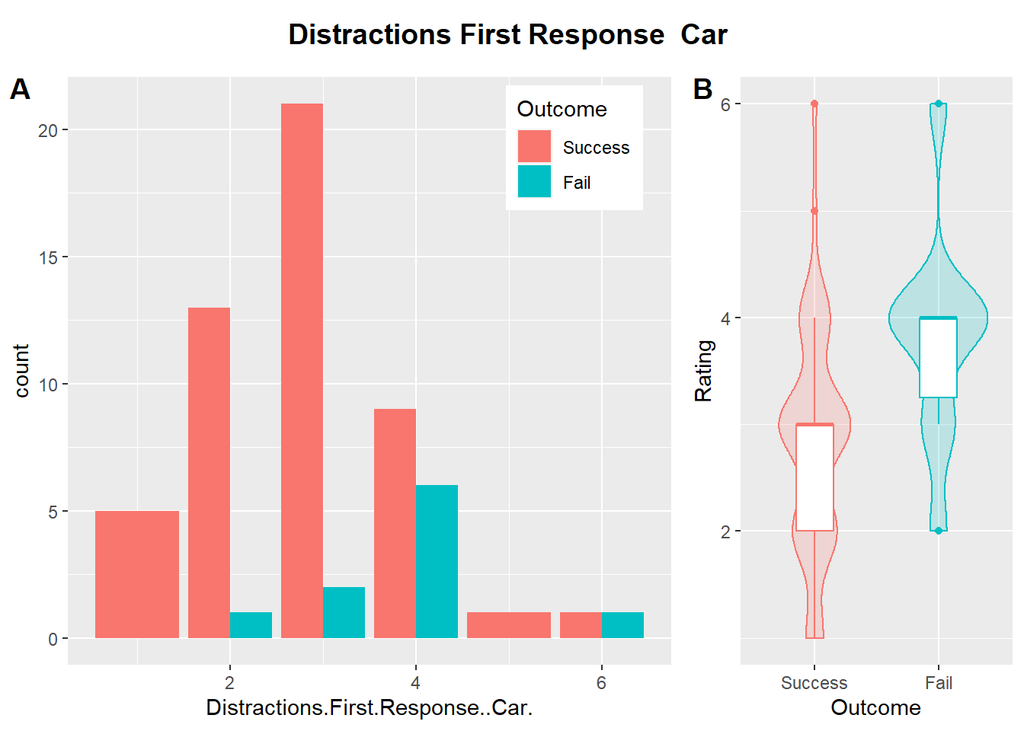

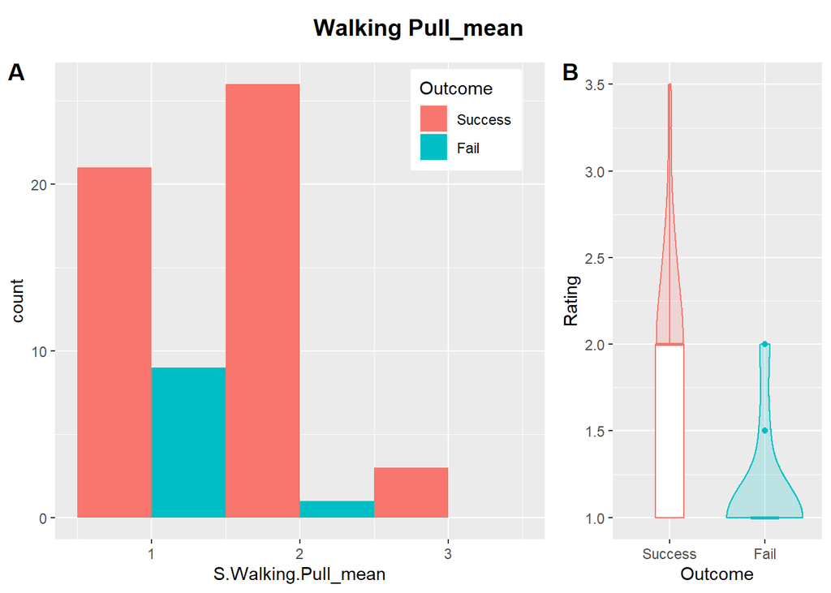

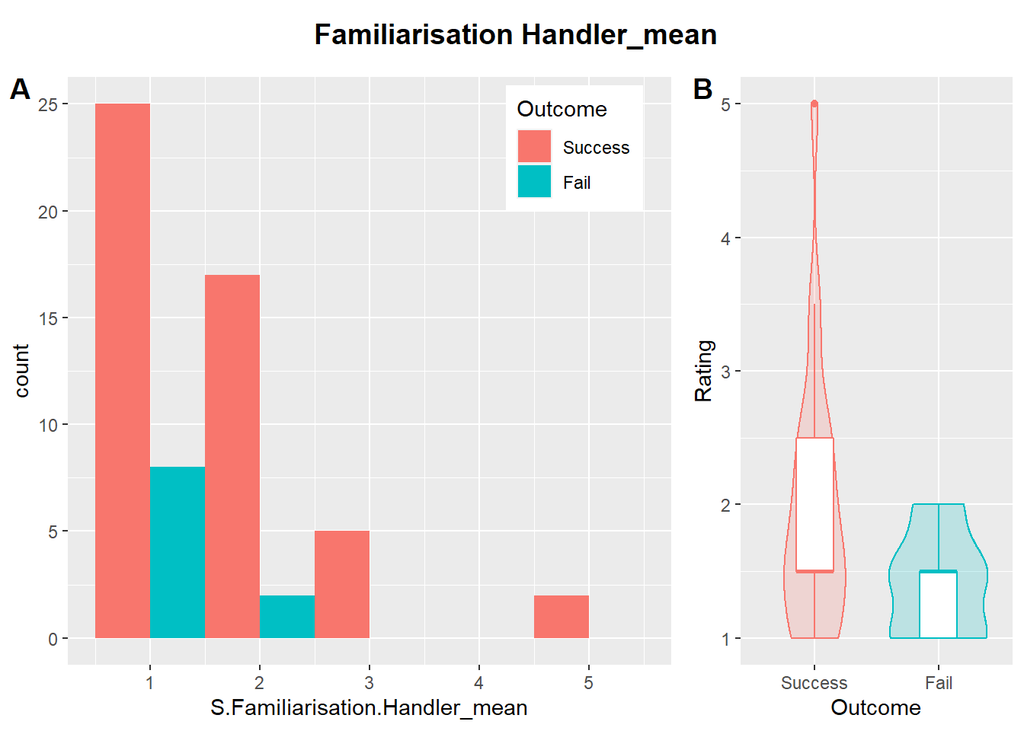

# 3 Multivariate Model

## 3.1 Preprocessing: Normalization + Imputation + PCA

## 3.2 Recursive Feature Elimination (RFE) + Multivariate Logistic Regression (LR)

```
## [1] "Distractions.First.Response..Car." "S.Walking.Pull_mean"
## [3] "S.Familiarisation.Handler_mean"    "Outcome"
```

```
## predicting second class: Fail Success
```

```
##
## Recursive feature selection
##
## Outer resampling method: Cross-Validated (60 fold)
##
## Resampling performance over subset size:
##
##  Variables AUC Precision Recall F AUCSD PrecisionSD RecallSD FSD Num_Resamples
##          1 NaN    0.4444    0.4 1    NA      0.5270   0.5164   0            60
##          2 NaN    0.6000    0.6 1    NA      0.5164   0.5164   0            60
##          3 NaN    0.6000    0.6 1    NA      0.5164   0.5164   0            60
##  Selected
##
##         *
##
##
## The top 2 variables (out of 2):
##    PC3, PC2
```

```
##
## Call:
## glm(formula = Class ~ ., family = "binomial", data = tmp)
##
## Deviance Residuals:
##      Min        1Q    Median        3Q       Max
## -2.39770   0.01021   0.04999   0.29185   1.67088
##
## Coefficients:
##             Estimate Std. Error z value Pr(>|z|)
## (Intercept)    4.611      1.461   3.157  0.00160 **
## PC3            3.425      1.133   3.023  0.00250 **
## PC2            3.122      1.193   2.617  0.00887 **
## ---
## Signif. codes:  0 '***' 0.001 '**' 0.01 '*' 0.05 '.' 0.1 ' ' 1
##
## (Dispersion parameter for binomial family taken to be 1)
##
##     Null deviance: 54.067  on 59  degrees of freedom
## Residual deviance: 24.779  on 57  degrees of freedom
## AIC: 30.779
##
## Number of Fisher Scoring iterations: 8
```

Model fitness with deviance analysis. Performance metrics ROC and PR curves.

```
##
## deviance difference:  29.28822
```

```
##
## df difference:  2
```

```
##
## level of significance:  4.366607e-07
```

```
##
## the model is a good fit:  TRUE
```

```
## Confusion Matrix and Statistics
##
##           Reference
## Prediction Fail Success
##    Fail       6       4
##    Success    4      46
##
##                Accuracy : 0.8667
##                  95% CI : (0.7541, 0.9406)
##     No Information Rate : 0.8333
##     P-Value [Acc > NIR] : 0.312
##
##                   Kappa : 0.52
##
##  Mcnemar's Test P-Value : 1.000
##
##             Sensitivity : 0.6000
##             Specificity : 0.9200
##          Pos Pred Value : 0.6000
##          Neg Pred Value : 0.9200
##              Prevalence : 0.1667
##          Detection Rate : 0.1000
##    Detection Prevalence : 0.1667
##       Balanced Accuracy : 0.7600
##
##        'Positive' Class : Fail
##
```

```
##
##   ROC curve
##
##     Area under curve:
##      0.926
##
##     Curve for scores from  5.350222e-09  to  0.9363929
##     ( can be plotted with plot(x) )
```

```
## Confusion Matrix and Statistics
##
##           Reference
## Prediction Fail Success
##    Fail       6       4
##    Success    4      46
##
##                Accuracy : 0.8667
##                  95% CI : (0.7541, 0.9406)
##     No Information Rate : 0.8333
##     P-Value [Acc > NIR] : 0.312
##
##                   Kappa : 0.52
##
##  Mcnemar's Test P-Value : 1.000
##
##               Precision : 0.6000
##                  Recall : 0.6000
##                      F1 : 0.6000
##              Prevalence : 0.1667
##          Detection Rate : 0.1000
##    Detection Prevalence : 0.1667
##       Balanced Accuracy : 0.7600
##
##        'Positive' Class : Fail
##
```

```
##
##   Precision-recall curve
##
##     Area under curve (Integral):
##      0.6891195
##
##     Area under curve (Davis & Goadrich):
##      0.6871063
##
##     Curve for scores from  5.350222e-09  to  0.9363929
##     ( can be plotted with plot(x) )
```

Plot the logit functions

```
## [1] "Probability predicted by the LR using PRQ data vs true Outcome"
```

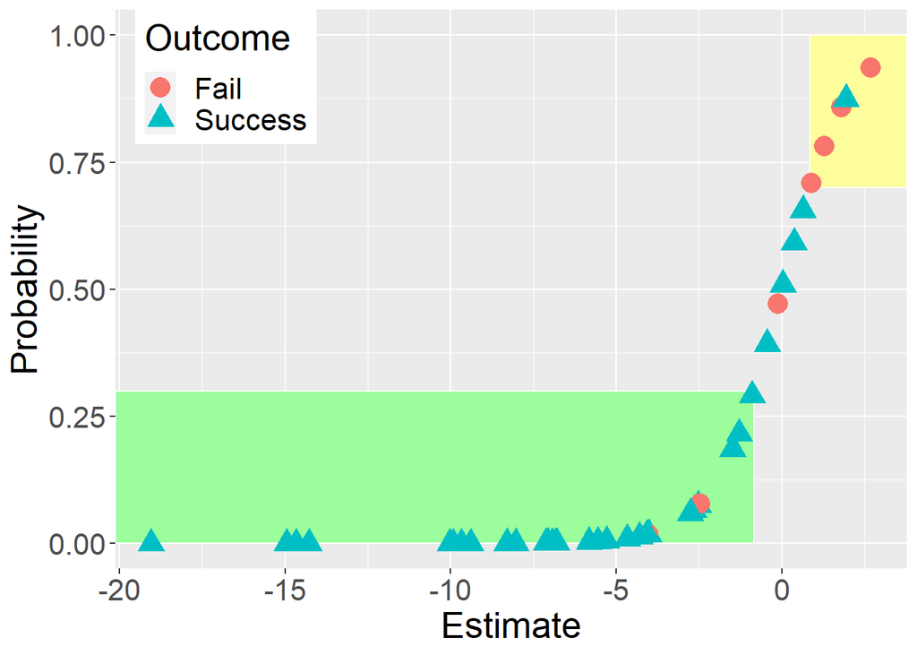

```
## [1] "Probability predicted by the LR using PRQ data vs true Status"
```

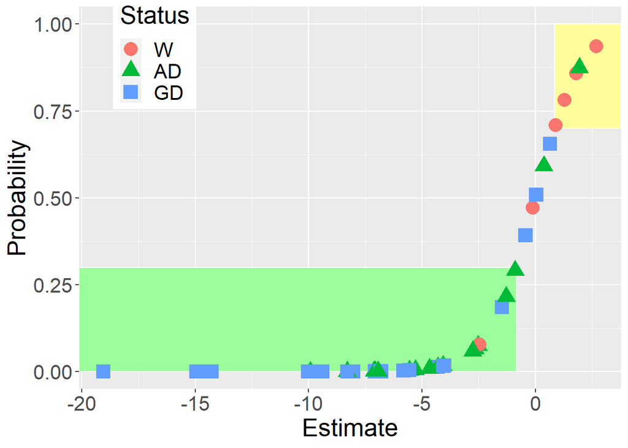

```
## [1] "Estimate and Probabilities per training outcome status"
```

```
## # A tibble: 3 × 2
##   Status   Mean
##   <fct>   <dbl>
## 1 W       0.211
## 2 AD     -4.06
## 3 GD     -7.04
```

```
## # A tibble: 3 × 2
##   Status   Mean
##   <fct>   <dbl>
## 1 W      0.582
## 2 AD     0.116
## 3 GD     0.0677
```

```
## Predicted probability < 0.3  -> Green flag
```

```
## [1] "Dogs flagged green are likely to SUCCEED, true outcome count and status proportion:"
```

```
##
##    Fail Success
##       2      45
```

```
##
##          W         AD         GD
## 0.04255319 0.44680851 0.51063830
```

```
## Predicted probability > 0.7 -> Yellow flag
```

[output not shown]

```
##
##    Fail Success
##       6       1
```

```
##
##      Fail   Success
## 0.8571429 0.1428571
```

```
##
##         W        AD        GD
## 0.8571429 0.1428571 0.0000000
```

```
## 0.3  < Predicted probability < 0.7 -> no flags
```

```
##
##  W AD GD
##  2  1  3
```

```
##
##         W        AD        GD
## 0.3333333 0.1666667 0.5000000
```

Check the dogs that were false positives or false negatives

```
##                  Index Probability
## predictions.1140    40   0.5091845
## predictions.1129    29   0.5917730
## predictions.1126    26   0.6554657
## predictions.1144    44   0.8746301
```

```
## [1] Jessie Jane   Josie  Lexie
## 61 Levels: Douglas Dugg Earl Ebbi Eddie Edrick Effie Eldin Elf Eliza ... Zodiac
```

```
##                  Index Probability
## predictions.1143    43  0.01753558
## predictions.1141    41  0.07843163
## predictions.1113    13  0.47194911
## predictions.1136    36  0.47194911
```

```
## [1] Meg    Zander Eliza  Meeko
## 61 Levels: Douglas Dugg Earl Ebbi Eddie Edrick Effie Eldin Elf Eliza ... Zodiac
```

## 3.3 Interpretation

Discuss model interpretation

```
## [1] "Results from the model created"
```

```
##             Estimate Std. Error  z value    Pr(>|z|)        OR     2.5 %
## (Intercept) 4.610911   1.460728 3.156584 0.001596291 100.57570 11.343780
## PC3         3.425202   1.133072 3.022933 0.002503376  30.72886  5.250725
## PC2         3.121783   1.192877 2.617020 0.008870120  22.68679  3.252454
##                97.5 %
## (Intercept) 4270.1995
## PC3          540.6558
## PC2          391.1095
```

```
## dataframe saved to  3_analysis/dc2-new/rfe-lr.csv
```

## 3.4 Feature Importance

### 3.4.1 Explained variance

```
## PCA features kept in the final model after RFE:  PC3 PC2
```

```
## [1] "Explained Variance per Principal Component (Scree Plot)"
```

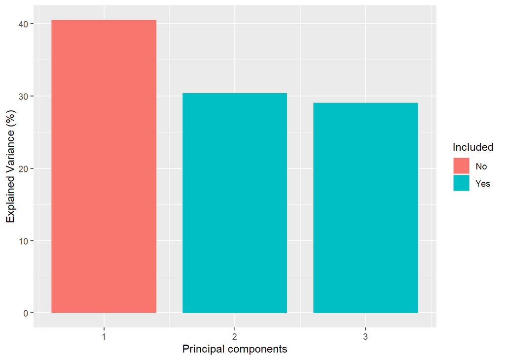

### 3.4.2 Coefficient loadings

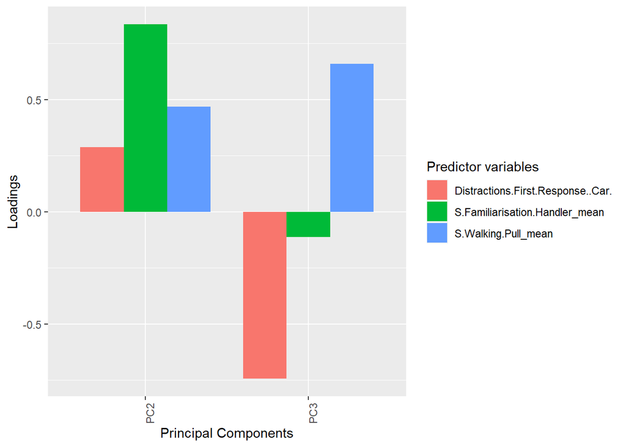

```
## dataframe saved to  3_analysis/dc2-new/pc-loading.csv
```

```
## [[1]]
##                               terms      value
## 1 Distractions.First.Response..Car. -0.7439590
## 2               S.Walking.Pull_mean  0.6587438
## 3    S.Familiarisation.Handler_mean -0.1121681
##
## [[2]]
##                               terms     value
## 1    S.Familiarisation.Handler_mean 0.8353362
## 2               S.Walking.Pull_mean 0.4679908
## 3 Distractions.First.Response..Car. 0.2884406
```

# 4 Conclusion